## Notas de aula de Mecânica Quântica Autor: Jonas Maziero

```python
%run init.ipynb
```

# Relações de incerteza

Vimos que a existência de observáveis incompatíveis, que não comutam, possibilita a preparação de estados de superposição que tem a eles associada uma "incerteza quântica" com relação a medidas futuras. Aqui usaremos o formalismo cinemático quântico para obter relações matemáticas gerais que fornecem limitações para o produto ou soma das "incertezas" (desvios padrões) sobre dois observáveis. Este texto é baseado, em parte, em https://arxiv.org/abs/1705.09139.

## Relação de incerteza de Heisenberg-Robertson-Schrödinger (RIHRS)

Aqui usaremos como uma das principais ferramentas a desigualdade de Cauchy-Scharz (DCS): \begin{equation} \langle\psi|\psi\rangle\langle\phi|\phi\rangle\ge|\langle\psi|\phi\rangle|^{2}, \end{equation} como igualdade obtida se e somente se $|\psi\rangle$ e $|\phi\rangle$ são colineares.

Considere $A$ e $B$ dois observáveis de um sistema físico preparado no estado $|\xi\rangle$. Usaremos $\langle X\rangle:=\langle X\rangle_{\xi}=\langle\xi|X|\xi\rangle$ para denotar o valor médio de um operador qualquer $X$ e $\mathbb{I}$ para o operador identidade $\mathcal{H}$. Vamos definir ainda os seguintes vetores: \begin{align} & |\psi\rangle=(A-\langle A\rangle\mathbb{I})|\xi\rangle, \\ & |\phi\rangle=(B-\langle B\rangle\mathbb{I})|\xi\rangle, \label{eq:states} \end{align} que substituiremos na DCS. Notemos que \begin{align} \langle\psi|\psi\rangle & = ((A-\langle A\rangle\mathbb{I})|\xi\rangle,(A-\langle A\rangle\mathbb{I})|\xi\rangle) \\ & = (|\xi\rangle,(A-\langle A\rangle\mathbb{I})^{\dagger}(A-\langle A\rangle\mathbb{I})|\xi\rangle) \\ & = \langle\xi|(A-\langle A\rangle\mathbb{I})^{2}|\xi\rangle \\ & = \mathrm{Var}(A), \\ \langle\phi|\phi\rangle & = \mathrm{Var}(B), \end{align} com $\mathrm{Var}(X)=\langle(X-\langle X\rangle\mathbb{I})^{2}\rangle$ sendo a variância de $X$.

Verifica-se que \begin{align} \langle\psi|\phi\rangle &= ((A-\langle A\rangle\mathbb{I})|\xi\rangle,(B-\langle B\rangle\mathbb{I})|\xi\rangle) \\ & = (|\xi\rangle,(A-\langle A\rangle\mathbb{I})(B-\langle B\rangle\mathbb{I})|\xi\rangle) \\ & = (|\xi\rangle,(AB-A\langle B\rangle-\langle A\rangle B+\langle A\rangle\langle B\rangle\mathbb{I})|\xi\rangle) \\ & = \langle AB-\langle A\rangle\langle B\rangle\mathbb{I}\rangle \\ & = 2^{-1}\langle\{A,B\}-2\langle A\rangle\langle B\rangle\mathbb{I}\rangle+2^{-1}\langle[A,B]\rangle \\ & = \Re(\langle\psi|\phi\rangle) + i \Im(\langle\psi|\phi\rangle) \\ & = 2^{-1}(\langle AB\rangle -\langle A\rangle\langle B\rangle + \langle BA\rangle - \langle A\rangle\langle B\rangle) + i(-i 2^{-1}\langle[A,B]\rangle) \end{align} onde \begin{align} & [A,B]=AB-BA, \\ & \{A,B\}=AB+BA \end{align} são, respectivamente, o comutador e anti-comutador de $A$ e $B$. Note que $$AB = 2^{-1}(\{A,B\}+[A,B]).$$ Como $\{A,B\}$ e $[A,B]$ são, respectivamente, operadores Hermitianos e anti-Hermitianos, seus valores médios são, respectivamente, números reais e imaginários puros. Assim, considerando que \begin{equation} |\langle\psi|\phi\rangle|^{2}=(\Re(\langle\psi|\phi\rangle))^{2}+(\Im(\langle\psi|\phi\rangle))^{2}, \end{equation} depois de algumas manipulações algébricas obteremos a RIHRS: \begin{equation} \color{blue}{\mathrm{Var}(A)\mathrm{Var}(B)\ge (\mathrm{CovQ}(A,B))^{2}+2^{-2}|\langle[A,B]\rangle|^{2}},\label{eq:RIHRS} \end{equation} onde \begin{equation} \mathrm{CovQ}(A,B)=2^{-1}(\mathrm{Cov}(A,B)+\mathrm{Cov}(B,A)) \end{equation} é a covariância quântica, com $$\mathrm{Cov}(X,Y)=\langle XY\rangle-\langle X\rangle\langle Y\rangle$$ sendo a covariância entre os observáveis $X$ e $Y$. Se $A$ e $B$ são observáveis compatíveis, i.e., se $[A,B]=\mathbb{0}$, teremos que $\mathrm{CovQ}(A,B)=\mathrm{Cov}(A,B)$.

Vamos analizar agora o **problema da possível trivialidade** da RIHRS, que tem por objetivo geral delimitar o quão pequeno pode ser o produto das variâncias de um par de observáveis. Mas, vamos assumir que o sistema está preparado em um estado que é autovetor do observável $A$, i.e., $|\xi\rangle=|a\rangle$ com $A|a\rangle=a|a\rangle$ e $a\in\mathbb{R}$. Neste caso pode-se verificar que \begin{equation} \mathrm{Var}(A)_{|a\rangle}=\mathrm{CovQ}(A,B)_{|a\rangle}=\langle[A,B]\rangle_{|a\rangle}=0. \end{equation} E com isso a RIHRS nos retorna \begin{equation} 0\mathrm{Var}(\hat{B})\ge0. \end{equation} Por conseguinte, neste caso, a RIHRS não fornece informação alguma sobre a possível incompatibilidade de $A$ e $B$. O mesmo tipo de limitação se aplica se $|\xi\rangle=|b\rangle$ para $B|b\rangle=b|b\rangle$.

### Relação de incerteza de Heisenberg (RIH)

Ignorando-se o termo relacionado à covariância quântica na RIHRS e tomando a raiz quadrada da expressão que resta, obtemos a *relação de incerteza de Robertson*: \begin{equation} \sigma_{A}\sigma_{B} \ge 2^{-1}|\langle[A,B]\rangle|, \end{equation} que quando aplicada a posição e momento linear é uma das *relações de incerteza de Heisenberg*: \begin{equation} \sigma_{X}\sigma_{P} \ge 2^{-1}|\langle[X,P]\rangle|=\hbar/2, \end{equation} pois $[X,P]=i\hbar\mathbb{I}$ (como verificaremos posteriormente).

Vale observar aqui que podemos usar a relação de incerteza de Robertson para obter uma relação que envolve a soma das variâncias: \begin{align} & (\sigma_{A}-\sigma_{B})^{2}\ge 0 \therefore \sigma_{A}^{2}+\sigma_{B}^{2}-2\sigma_{A}\sigma_{B}\ge 0 \\ & Var(A)+Var(B) \ge 2\sigma_{A}\sigma_{B} \ge |\langle[A,B]\rangle|. \end{align} Mas essa nova relação também sofre do problema da trivialidade.

## Relação de incerteza de Maccone-Pati (RIMP)

Essa relação de incerteza lê-se: \begin{equation} \color{blue}{\mathrm{Var}(A)+\mathrm{Var}(B) \ge \max\left(\frac{1}{2}|\langle\xi|(A\pm B)|\xi_{\perp}\rangle|^{2},\pm i\langle[A,B]\rangle + |\langle\xi|(A\pm iB)|\xi_{\perp}\rangle|^{2}\right)} \end{equation} com $|\xi_{\perp}\rangle$ sendo qualquer vetor normalizado e ortogonal a $|\xi\rangle$ e o sinal é escolhido de forma a maximizar o limite inferior.

Para provar a RIMP, começamos com a regra dos paralelogramos: \begin{equation} 2(|||\psi\rangle||^{2}+|||\phi\rangle||^{2}) = |||\psi\rangle+|\phi\rangle||^{2} + |||\psi\rangle-|\phi\rangle||^{2}. \end{equation}

Como fizemos no caso da RIHRS, começamos definindo $|\psi\rangle=(A-\langle A\rangle\mathbb{I})|\xi\rangle \Rightarrow |||\psi\rangle||^{2}=\mathrm{Var}(A)$ e $|\phi\rangle=(B-\langle B\rangle\mathbb{I})|\xi\rangle \Rightarrow |||\phi\rangle||^{2}=\mathrm{Var}(B)$ para escrever \begin{align} \mathrm{Var}(A)+\mathrm{Var}(B) & = ||\phi||^{2}+||\psi||^{2} \\ & = \frac{1}{2}\left(||(|\psi\rangle+|\phi\rangle)||^{2} + |||(\psi\rangle-|\phi\rangle)||^{2}\right) \\ & \ge \frac{1}{2}|||\psi\rangle|\pm|\phi\rangle||^{2} \\ & = \frac{1}{2}(\langle\psi|\pm\langle\phi|)(|\psi\rangle\pm|\phi\rangle)\langle\xi_{\perp}|\xi_{\perp}\rangle \\ & \ge \frac{1}{2}|(\langle\psi|\pm\langle\phi|)|\xi_{\perp}\rangle|^{2} \\ & = \frac{1}{2}|(\langle\xi|(A-\langle A\rangle\mathbb{I})\pm\langle\xi|(B-\langle B\rangle\mathbb{I}))|\xi_{\perp}\rangle|^{2} \\ & = \frac{1}{2}|\langle\xi|(A\pm B)|\xi_{\perp}\rangle - (\langle A\rangle\pm \langle B\rangle)\langle\xi|\xi_{\perp}\rangle|^{2} \\ &= \frac{1}{2}|\langle\xi|(A\pm B)|\xi_{\perp}\rangle|^{2}. \end{align} Para a primeira desigualdade usamos a positividade da norma, a para a segunda desigualdade usamos a desigualdade de Cauchy-Scharz.

Para obter o segundo limite inferior, começamos notando que \begin{align} ||\psi\pm i\phi||^{2} & = (\langle\psi|\mp i\langle\phi|)(|\psi\rangle\pm i|\phi\rangle) \\ & = ||\psi||^{2}+||\phi||^{2}\pm i(\langle\psi|\phi\rangle-\langle\phi|\psi\rangle) \\ & = ||\psi||^{2}+||\phi||^{2}\pm i2i\Im(\langle\psi|\phi\rangle). \end{align} Vimos que \begin{equation} \langle\psi|\phi\rangle=CovQ(A,B)+i(-i\langle[A,B]\rangle/2). \end{equation} Assim \begin{align} ||\psi\pm i\phi||^{2} & = ||\psi||^{2}+||\phi||^{2}\pm i2i(-i\langle[A,B]\rangle/2). \end{align} Com isso, podemos escrever \begin{align} Var(A)+Var(B) & = ||\psi||^{2}+||\phi||^{2} \\ & = ||\psi\pm i\phi||^{2} \mp i\langle[A,B]\rangle \\ & = (\langle\psi|\mp i\langle\phi|)(|\psi\rangle\pm i|\phi\rangle)\langle\xi_{\perp}|\xi_{\perp}\rangle \mp i\langle[A,B]\rangle \\ & \ge |(\langle\psi|\mp i\langle\phi|)|\xi_{\perp}\rangle|^{2} \mp i\langle[A,B]\rangle \\ & = |(\langle\xi|(A-\langle A\rangle\mathbb{I})\mp i\langle\xi|(B-\langle B\rangle\mathbb{I}))|\xi_{\perp}\rangle|^{2} \mp i\langle[A,B]\rangle \\ & = |\langle\xi|(A\mp iB)|\xi_{\perp}\rangle+|(\langle A\rangle\mp i\langle B\rangle)\langle\xi|\xi_{\perp}\rangle|^{2} \mp i\langle[A,B]\rangle \\ & = |\langle\xi|(A\mp iB)|\xi_{\perp}\rangle|^{2} \mp i\langle[A,B]\rangle. \end{align}

Vale observar que esses limites inferiores na RIMP serão nulos somente se $|\xi\rangle$ for autovetor simultâneo de $A$ e de $B$.

### Exemplo:

#### Relação de incerteza entre campo elétrico (fase) e o número de fótons (intensidade) do campo eletromagnético quantizado

Um modo de oscilação do campo eletromagnético dentro de uma cavidade, quando quantizado, é descrito pelo Hamiltoniano do oscilador harmônico quântico unidimensional: \begin{equation} H = \hbar\omega(N+\mathbb{I}/2), \end{equation} onde $N=a^{\dagger}a$ é o operador número e $a^{\dagger}$ e $a$ são os operadores de criação e aniquilação, respectivamente. Da solução analítica para os autovalores de $H$, sabe-se que \begin{equation} N|n\rangle = n|n\rangle\text{, } a|n\rangle = \sqrt{n}|n-1\rangle \text{, } a^{\dagger}|n\rangle = \sqrt{n+1}|n+1\rangle, \end{equation} onde $n = 0, 1, 2, \cdots, \infty$. O operador Hermitiano que descreve o campo elétrico é \begin{equation} E_{x} = E_{0x}\sin(kz)(a+a^{\dagger}) =: E(a+a^{\dagger})\propto \text{ quadratura } X, \end{equation} com $E_{0x}$ e $k$ sendo escalares reais. Vamos considerar o campo preparado no seguinte estado de superposição: \begin{equation} |\xi\rangle = \cos\theta|0\rangle+\sin\theta|1\rangle, \end{equation} e vamos calcular as variâncias de $N$ e de $E_{x}$ e os limites inferiores dados pelas RIHRS e RIMP para essas quantidades.

#### Variâncias

Para o operador número: \begin{align} \langle N\rangle_{\xi} & = \langle\xi|N(\cos\theta|0\rangle+\sin\theta|1\rangle) \\ & = \langle\xi|(\cos\theta N|0\rangle+\sin\theta N|1\rangle) \\ & = (\cos\theta\langle 0|+\sin\theta\langle 1|)(\cos\theta (0)|0\rangle+\sin\theta (1)|1\rangle) \\ & = \sin^{2}\theta \\ & = \langle N^{2}\rangle_{\xi}, \\ \mathrm{Var}(N) & = \langle N^{2}\rangle_{\xi} - \langle N\rangle_{\xi}^{2} = \sin^{2}\theta\cos^{2}\theta. \end{align}

Note que $|\xi\rangle$ não é autovetor de $E_{x}$ para nenhum valor de $\theta$ pois \begin{equation} (a+a^{\dagger})|\xi\rangle = \sin\theta|0\rangle + \cos\theta|1\rangle + \sqrt{2}\sin\theta|2\rangle, \end{equation} ou seja, $\sigma_{E_{x}}>0$. Aqui \begin{align} \langle E_{x}\rangle_{\xi} & = E\langle\xi|(a+a^{\dagger})|\xi\rangle \\ & = E(\cos\theta\langle 0|+\sin\theta\langle 1|)(\sin\theta|0\rangle + \cos\theta|1\rangle + \sqrt{2}\sin\theta|2\rangle) \\ & = E2\sin\theta\cos\theta \\ & = E\sin 2\theta, \\ \langle E_{x}^{2}\rangle_{\xi} & = E^{2} \langle\xi|(a+a^{\dagger})(a+a^{\dagger})|\xi\rangle = E^{2} \langle\xi|(a+a^{\dagger})(\sin\theta|0\rangle + \cos\theta|1\rangle + \sqrt{2}\sin\theta|2\rangle) \\ & = E^{2} (\cos\theta\langle 0|+\sin\theta\langle 1|)(0 + \cos\theta|0\rangle + 2\sin\theta|1\rangle + \sin\theta|1\rangle + \sqrt{2}\cos\theta|2\rangle + \sqrt{6}\sin\theta|3\rangle) \\ & = E^{2} (\cos^{2}\theta + 3\sin^{2}\theta) \\ & = E^{2} (1 + 2\sin^{2}\theta) = E^{2} (1 + 2\frac{1-\cos 2\theta}{2}) \\ & = E^{2} (2-\cos 2\theta), \\ \mathrm{Var}(E_{x}) & = \langle E_{x}^{2}\rangle_{\xi} - \langle E_{x}\rangle_{\xi}^{2} = E^{2}(2 - \cos2\theta - \sin^{2}2\theta). \end{align}

#### Limites inferiores

Usaremos $[a,a^{\dagger}]=\mathbb{I}$ para obter o comutador de $N$ com $E_{x}$: \begin{align} [N,E_{x}] & = E([a^{\dagger}a,a] + [a^{\dagger}a,a^{\dagger}]) \\ & = E(a^{\dagger}[a,a] + [a^{\dagger},a]a + a^{\dagger}[a,a^{\dagger}] + [a,a^{\dagger}]a^{\dagger}) \\ & = E(-a + a^{\dagger}) \propto \text{ quadratura } P. \end{align} Valor médio do comutador: \begin{align} \langle[N,E_{x}]\rangle_{\xi} & = E\langle\xi|(-a + a^{\dagger})(\cos\theta|0\rangle+\sin\theta|1\rangle) \\ & = E(\cos\theta\langle0|+\sin\theta\langle1|)(0-\sin\theta|0\rangle+\cos\theta|1\rangle+\sqrt{2}\sin\theta|2\rangle) \\ & = E(-\sin\theta\cos\theta + \sin\theta\cos\theta) \\ & = 0. \end{align}

Para o anticomutador teremos \begin{align} \{N,E_{x}\} & = E(\{a^{\dagger}a,a\} + \{a^{\dagger}a,a^{\dagger}\}) \\ & = E(a^{\dagger}aa + aa^{\dagger}a + a^{\dagger}aa^{\dagger} + a^{\dagger}a^{\dagger}a). \end{align} Notemos que \begin{align} & a^{\dagger}aa|\xi\rangle = 0,\\ & aa^{\dagger}a|\xi\rangle = \sin\theta|0\rangle,\\ & a^{\dagger}aa^{\dagger}|\xi\rangle = \cos\theta|1\rangle + 2\sqrt{2}\sin\theta|2\rangle, \\ & a^{\dagger}a^{\dagger}a = \sqrt{2}\sin\theta|2\rangle. \end{align} Assim \begin{align} \langle\{N,E_{x}\}\rangle_{\xi} & = E\langle\xi|(a^{\dagger}aa + aa^{\dagger}a + a^{\dagger}aa^{\dagger} + a^{\dagger}a^{\dagger}a)|\xi\rangle \\ & = E(\cos\theta\langle\xi|+\sin\theta\langle1|)i(0 + \sin\theta|0\rangle + \cos\theta|1\rangle + 2\sqrt{2}\sin\theta|2\rangle + \sqrt{2}\sin\theta|2\rangle)|\xi\rangle \\ & = E(2\sin\theta\cos\theta) \\ & = E\sin2\theta. \end{align}

Covariância quântica \begin{align} \mathrm{CovQ}(N,E_{x})_{\xi} & = (\mathrm{Cov}(N,E_{x})_{\xi} + \mathrm{Cov}(E_{x},N)_{\xi})/2 \\ & = \left(\langle NE_{x}\rangle_{\xi} - \langle N\rangle_{\xi}\langle E_{x}\rangle_{\xi} + \langle E_{x}N\rangle_{\xi} - \langle N\rangle_{\xi}\langle E_{x}\rangle_{\xi} \right)/2 \\ & = 2^{-1}\langle\{N,E_{x}\}\rangle_{\xi} - \langle N\rangle_{\xi}\langle E_{x}\rangle_{\xi} \\ & = 2^{-1}E\sin2\theta - \sin^{2}\theta E\sin2\theta \\ & = E\sin2\theta(2^{-1} - \sin^{2}\theta). \end{align}

Limite inferior para a RIHRS: \begin{align} L_{hrs} & = (\mathrm{CovQ}(N,E_{x}))^{2} + 2^{-2}|\langle[N,E_{x}]\rangle|^{2} \\ & = \left(E\sin2\theta(2^{-1} - \sin^{2}\theta)\right)^{2} + 0. \end{align}

Limite inferior para a RIMP: \begin{align} L_{mp} & = \frac{1}{2}|\langle\xi_{\perp}|(N\pm E_{x})|\xi\rangle|^{2} \\ & = \frac{1}{2}|\langle\xi_{\perp}|(a^{\dagger}a\pm E(a+a^{\dagger}))(\cos\theta|0\rangle+\sin\theta|1\rangle)|^{2} \\ & = \frac{1}{2}|\langle\xi_{\perp}|(0+\sin\theta|1\rangle\pm E(0+\sin\theta|0\rangle +\cos\theta|1\rangle+\sqrt{2}\sin\theta|2\rangle))|^{2} \\ & = \frac{1}{2}|\langle\xi_{\perp}|((\sin\theta \pm E \cos\theta)|1\rangle \pm E(\sin\theta|0\rangle +\sqrt{2}\sin\theta|2\rangle))|^{2}. \end{align} A escolha mais simples para $|\xi_{\perp}\rangle$ seria $|2\rangle$. Mas nesse caso $L_{mp}=\sin^{2}\theta$ será trivial para $\theta=0,\pi$. Uma possibilidade mais geral seria \begin{equation} |\xi_{\perp}\rangle = \frac{1}{\sqrt{2}}\left(\sin\theta|0\rangle - \cos\theta|1\rangle + |2\rangle\right). \end{equation} Nesse caso teremos \begin{align} L_{mp} & = \frac{1}{2}\left| \pm\frac{E\sin^{2}\theta}{\sqrt{2}} -\frac{\cos\theta}{\sqrt{2}}(\sin\theta\pm E\cos\theta) \pm\frac{E\sqrt{2}\sin\theta}{\sqrt{2}} \right|^{2} \\ & = \cdots \\ & = \left|\mp\frac{E\cos2\theta}{2} -\frac{\sin2\theta}{4} \pm \frac{E\sin\theta}{\sqrt{2}} \right|^{2}. \end{align} Ainda temos pontos de trivialidade! (outro $|\xi_{\perp}\rangle$?)

Por outro lado, podemos olhar para o outro limite inferior da RIMP. Usamos \begin{align} \langle\xi_{\perp}|(N\pm iE_{x})|\xi\rangle & = \langle\xi_{\perp}|(N\pm iE(a+a^{\dagger}))(\cos\theta|0\rangle+\sin\theta|1\rangle) \\ & = \langle\xi_{\perp}|(\sin\theta|1\rangle\pm iE(\sin\theta|0\rangle+\cos\theta|1\rangle+\sqrt{2}\sin\theta|2\rangle)) \\ & = \frac{\sin\theta\cos\theta}{\sqrt{2}} \pm \frac{iE}{\sqrt{2}}(\sin^{2}\theta-\cos^{2}\theta+\sqrt{2}\sin\theta) \\ & = \frac{\sin2\theta}{2\sqrt{2}} \pm \frac{iE}{\sqrt{2}}(-\cos2\theta+\sqrt{2}\sin\theta) \end{align} \begin{align} \tilde{L}_{mp} & = \pm i\langle[N,E_{x}]\rangle + |\langle\xi_{\perp}|(N\pm iE_{x})|\xi\rangle|^{2} \\ & = 0 + \frac{\sin^{2}2\theta}{8} + \frac{E^{2}}{2}\left(-\cos2\theta+\sqrt{2}\sin\theta\right)^{2}. \end{align} Aqui usamos o mesmo $|\xi_{\perp}\rangle$ que acima. Nesse caso não há problema de trivialidade para nenhum valor de $\theta$.

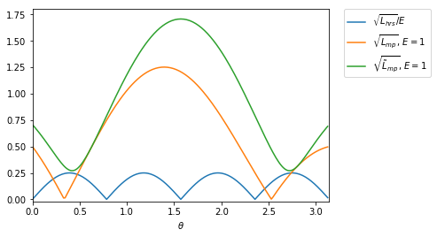

```python
N = 200; dth = (np.pi-0)/N; Nm = np.zeros(N)
VarN = np.zeros(N); Em = np.zeros(N); E = 1
VarE = np.zeros(N); Lhrs = np.zeros(N); Lmp = np.zeros(N)
Lmpt = np.zeros(N); thv = np.zeros(N)
th = -dth
for j in range(0,N):
    th += dth; thv[j] = th; Nm[j] = (sin(th))**2
    VarN[j] = abs(sin(th)*cos(th))
    Em[j] = sin(2*th); VarE[j]=sqrt(2-cos(2*th)-(sin(2*th))**2)
    Lhrs[j] = abs(sin(2*th)*(0.5-(sin(th))**2))
    Lmp[j] = abs(+cos(2*th)/2 - sin(2*th)/4 - sin(th)/sqrt(2))
    Lmpt[j] = sqrt(sin(2*th)**2/8 + \
                   (E**2/2)*(-cos(2*th)+math.sqrt(2)*sin(th))**2)
plt.plot(thv, Lhrs, label=r'$\sqrt{L_{hrs}}/E$')
plt.plot(thv, Lmp, label=r'$\sqrt{L_{mp}}$, $E=1$')
plt.plot(thv, Lmpt, label=r'$\sqrt{\tilde{L}_{mp}}$, $E=1$')
plt.xlabel(r'$\theta$'); axes = plt.gca()
axes.set_xlim([0,np.pi]); axes.set_ylim([-0.02,1.8])
plt.legend(bbox_to_anchor=(1.05, 1),loc='upper left',borderaxespad=0.)
plt.show()
```

## Tópicos relacionados

Aqui vimos as chamadas relações de incerteza de preparação, onde, para um quanton preparado em um estado qualquer $|\xi\rangle$, obtivemos limites inferiores para o produto ou soma das variâncias de dois observáveis quaisquer daquele sistema quântico. Mas relações de incerteza foram desenvolvidas em várias direções e têm múltiplas aplicações. Você aprenderá mais sobre esse assunto procurando por:

- Relações de incerteza entrópicas (veja e.g. https://arxiv.org/abs/1511.04857);
- Relações de incerteza com memórias quânticas (veja e.g. https://arxiv.org/abs/0909.0950);
- Relações de incerteza para medidas conjuntas (veja e.g. https://arxiv.org/abs/quant-ph/0310070);
- Relações de limitação entre informação adiquirida e perturbação do estado do sistema (veja e.g. https://arxiv.org/abs/1505.01320);
- Relações de incerteza envolvendo parâmetros que não são representados por operadores Hermitianos, tais como tempo e fase (veja e.g. https://arxiv.org/abs/quant-ph/0105049).
- Verificação experimental de relações de incerteza (veja e.g. https://arxiv.org/abs/1407.7752).
- Complementaridade quântica (veja e.g. https://arxiv.org/abs/2011.00723).

## Relação de incerteza energia-tempo (RIET)

O tempo é só um parâmetro em MQ, não existe um operador Hermitiano que o represente. A seguir obteremos o que se chama de RIET, clarificando a que tempo essa relação se refere. Consideremos a eq. de Heisenberg (para observáveis que não dependem explicitamente do tempo na representação de Schrödinger), \begin{equation} i\hbar\partial_{t}O_{t}^{H} = [O_{t}^{H},H_{t}^{H}], \end{equation} e a relação de incerteza de Robertson: \begin{equation} \sigma_{O_{t}}\sigma_{H_{t}} \ge 2^{-1}|\langle[O_{t}^{H},H_{t}^{H}]\rangle|. \end{equation} Teremos assim que \begin{align} |\langle i\hbar\partial_{t}O_{t}^{H}\rangle| & = \hbar|\partial_{t}\langle O_{t}\rangle| \\ & = |\langle[O_{t}^{H},H_{t}^{H}]\rangle| \\ & \le 2\sigma_{O_{t}}\sigma_{H_{t}}. \end{align} Se $O$ não é uma constante de movimento, i.e., se $\partial_{t}\langle O_{t}\rangle \ne 0$, podemos escrever a seguinte desigualdade: \begin{equation} \sigma_{H_{t}}\frac{\sigma_{O_{t}}}{|\partial_{t}\langle O_{t}\rangle|} \ge \frac{\hbar}{2}. \end{equation} Definiremos agora a seguinte escala de tempo \begin{equation} \Delta t_{O} := \frac{\sigma_{O_{t}}}{|\partial_{t}\langle O_{t}\rangle|}, \end{equation} o que nos leva à RIET: \begin{equation} \color{blue}{\sigma_{H_{t}}\Delta t_{O} \ge \frac{\hbar}{2}}. \end{equation} Note que o tempo que aparece nessa expressão não é em geral aquele medido com relógio, mas sim a razão entre a largura da distribuição de probabilidades de $O$ no tempo $t$ e a taxa de mudança do centro dessa distribuição nesse instante.

### Limite de rapidez para mudanças de estados quânticos

Consideremos o sistema inicialmente preparado no estado $|\xi\rangle$. Vamos escrever o estado evoluído como \begin{equation} |\xi_{t}\rangle = \cos\theta_{t}|\xi\rangle + \sin\theta_{t}|\xi_{\perp}\rangle, \end{equation} com $\langle\xi|\xi_{\perp}\rangle=0$. Na RIET usamos o operador Hermitiano $O = |\xi\rangle\langle\xi|$ e faremos as contas na representação de Schrödinger considerando um Hamiltoniano independente do tempo: \begin{align} & \langle O^{2}_{t}\rangle = \langle O_{t}\rangle = \langle\xi_{t}|\xi\rangle\langle\xi|\xi_{t}\rangle = \cos^{2}\theta_{t}, \\ & \sigma_{O_{t}} = \sqrt{\langle O^{2}_{t}\rangle - \langle O_{t}\rangle^{2}} = \sqrt{\cos^{2}\theta_{t}(1-\cos^{2}\theta_{t})} = |\sin\theta_{t}\cos\theta_{t}|, \\ & \partial_{t}\langle O_{t}\rangle = -2\cos\theta_{t}\sin\theta_{t}\partial_{t}\theta_{t}, \\ & \Delta t_{O} = \frac{|\sin\theta_{t}\cos\theta_{t}|}{|-2\cos\theta_{t}\sin\theta_{t}\partial_{t}\theta_{t}|} = \frac{1}{2|\partial_{t}\theta_{t}|}, \\ & \Delta t_{O} \ge \frac{\hbar}{2\sigma_{H_{t}}} \Rightarrow \frac{1}{2|\partial_{t}\theta_{t}|} \ge \frac{\hbar}{2\sigma_{H_{t}}} \Rightarrow \frac{\sigma_{H}}{\hbar} \ge |\partial_{t}\theta_{t}| \Rightarrow \int_{0}^{t}\frac{\sigma_{H}}{\hbar}dt' \ge \int_{0}^{t}|\partial_{t'}\theta_{t'}|dt' \\ & \Rightarrow \frac{\sigma_{H}t}{\hbar} \ge \theta_{t} \Rightarrow t \ge \frac{\hbar\theta_{t}}{\sigma_{H}}. \end{align} Então o tempo necessário para obtermos a transição de $|\xi\rangle$ para o estado ortogonal $|\xi_{\perp}\rangle$ ($\theta_{t}=\pi/2$) é limitado por: \begin{equation} \color{blue}{t_{\perp} \ge \frac{\hbar\pi}{\sigma_{H}2}}, \end{equation} ou seja, quanto maior a largura da distribuição de probabilidades do Hamiltoniano em um estado, mas rápido este estado pode mudar com o tempo. Para mais detalhes, veja e.g. (https://arxiv.org/abs/1705.08023).

# Exercícios

1. Prove a desigualdade de Cauchy-Scharz, $\langle\psi|\psi\rangle\langle\phi|\phi\rangle\ge|\langle\psi|\phi\rangle|^{2}\hspace{0.2cm}\forall |\psi\rangle,|\phi\rangle\in\mathcal{H}$. Verifique que a igualdade é obtida se e somente se os vetores $|\psi\rangle$ e $|\phi\rangle$ são proporcionais.
2. Para $|\phi\rangle=(B-\langle B\rangle\mathbb{I})|\xi\rangle$ e $B=B^{\dagger}$, verifique que $\langle\phi|\phi\rangle=Var(B)$.
3. Verifique que se $[A,B]=\mathbb{0}$, então $CovQ(A,B)=Cov(A,B)=Cov(B,A)$.
4. Verifique que o comutador de dois operadores Hermitianos $A=A^{\dagger}$ e $B=B^{\dagger}$ é um operador anti-Hermitiano, i.e., $[A,B]^{\dagger}=-[A,B]$. Verifique que os autovalores (e portanto o valor médio) desse tipo de operador são números imaginários puros.
5. Verifique que se o estado no qual o sistema quântico foi preparado for um autovetor do observável $A$, i.e., $|\xi\rangle=|a\rangle$ com $A|a\rangle=a|a\rangle$, então $\mathrm{Var}(A)_{\xi}=\mathrm{CovQ}(A,B)_{\xi}=\langle[A,B]\rangle_{\xi}=0$ (claro, o mesmo se verifica se $|\xi\rangle=|b\rangle$ com $B|b\rangle=b|b\rangle$).
6. Usando que $\sigma_{j}\sigma_{k}=2i\epsilon_{jkl}\sigma_{l}$ é válido para as matrizes de Pauli, verifique que $\{\sigma_{j},\sigma_{k}\}=0$ para todo $j,k=1,2,3$ com $j\ne k$.
7. Considerando o grau de liberdade de spin 1/2, calcule as variâncias e o limite inferior para o produto das variâncias dos observáveis representados por $\sigma_{x}$ e $\sigma_{z}$ para o sistema no estado $|\xi\rangle = \cos(\theta/2)|z_{+}\rangle+\sin(\theta/2)|z_{-}\rangle$. Faça o gráfico de $\mathrm{Var}(\sigma_{x})$, $\mathrm{Var}(\sigma_{z})$, $\mathrm{Var}(\sigma_{x})\mathrm{Var}(\sigma_{z})$ e do limite inferior da RIHRS para esse produto em função de $\theta\in[0,\pi]$.
8. Verifique a validade geral da regra do paralelogramo $2(|||\psi\rangle||^{2}+|||\phi\rangle||^{2}) = |||\psi\rangle+|\phi\rangle||^{2} + |||\psi\rangle-|\phi\rangle||^{2}$.
9. Calcule os limites inferiores na RIMP considerando o mesmo estado preparado e par de observáveis considerados no exercício 7. Discuta a vantagem de usarmos a RIMP no lugar da RIHRS nos casos em que $|\xi\rangle$ é autovetor de algum daqueles observáveis.
10. Verifique que se um certo Hamiltoniano é independente do tempo, então seu desvio padrão é constante.
11. Considere o Hamiltoniano $H=-2^{-1}\hbar\omega\sigma_{z}$ e o estado inicial $|x_{+}\rangle$. Mostre que o tempo mínimo para que o estado evoluído seja $|x_{-}\rangle$ é igual a $\pi/\omega$ e que o limite inferior da relação $t_{\perp}\ge \pi\hbar/2\sigma_{H}$ é $\pi/\omega$.